# 203 Assignment 1

## Introduction

This assignment is going to use the principles of energy balance to examine how changing properties of urban environments alter the temperature of urban landscapes. In urban areas, the distribution of materials such as asphalt and concrete has been shown to lead to higher air temperatures compared to rural counterparts. This is known as the urban heat island (UHI) effect. High temperatures can be harmful to the health of residents, and in order to mitigate the UHI cities adopt strategies like increasing tree cover to increase shade and cooling, or increasing the reflectivity, also called albedo, with white paint. However, these strategies are not always evenly distributed throughout a city and may create environmental inequity. Read more about this phenomena [here](https://docs.google.com/document/d/1NUJATMo7KnmC3PpyFRdxo9HWH0F-zQxUDKiIW6pX7pY/edit#heading=h.z1slrwcvefnj).

We’ve assembled a dataset that captures a snapshot of average midday temperatures in August, the amount of vegetation, and a host of social/economic data across each neighborhood in the county of Los Angeles. The temperature data is from the Landsat satellite’s surface thermal data and was acquired in the Spring (April) and Summer (August) of 2020. The vegetation data is characterized by the Normalized Difference Vegetation Index (NDVI), and is taken from similar dates. [NDVI](https://earthobservatory.nasa.gov/features/MeasuringVegetation/measuring_vegetation_2.php) is a measure of “greenness” and higher values of NDVI indicate a greater amount of green vegetation within each neighborhood. The neighborhood information is collated from the incredibly awesome Mapping LA project developed by the [LA Times](http://maps.latimes.com/neighborhoods), which is worth checking out. See a description of each column in the dataset at this

[link](https://docs.google.com/spreadsheets/d/1Hh-hMt5RuXA3lBYX8G16T3334zXQfbFnJzCxh3qbDsw/edit?usp=sharing). For a visual reference of the LA times project, here is a map of the area of the LA basin and the neighborhoods:

[figure not shown]

*Note If the photo above does not show, you need to set your working directory. In the menu at the top, click “Session” -> “Set Working Directory,” and navigate to the “Assignment1_forStudents” folder.*

### Part I: Exploring Los Angeles County Data

#### Observations

Lets start by just exploring our data. One of the first things we’d want to explore is what data is there. Run the code below to load the data and output the column names of all the data.

```r
# load in data as a CSV
LA_nbhds <- read.csv("ESM203_F2020_Ass1.csv")

# output column names
colnames(LA_nbhds)
```

```
##  [1] "NEIGHBORHOOD"        "POPULATION.PER.SQMI" "SINGLE.PARENTS"
##  [4] "ASIAN.POPULATION"    "LATINO.POPULATION"   "WHITE.POPULATION"
##  [7] "CRIME.PER.CAPITA"    "CRIME.TOTAL"         "DIVERSITY.INDEX"
## [10] "MEDIAN.INCOME"       "HOMEOWNERS"          "BLACK.POPULATION"
## [13] "NDVI_SPRING"         "NDVI_SUMMER"         "TEMP_SPRING"
## [16] "TEMP_SUMMER"
```

```r
summary(LA_nbhds)
```

```
##                  NEIGHBORHOOD POPULATION.PER.SQMI SINGLE.PARENTS
##  Adams-Normandie       :  2   Min.   :    2       Min.   :0.0000
##  Arlington Heights     :  2   1st Qu.: 3594       1st Qu.:0.1000
##  Baldwin Hills/Crenshaw:  2   Median : 9122       Median :0.1500
##  Boyle Heights         :  2   Mean   : 9657       Mean   :0.1587
##  Broadway-Manchester   :  2   3rd Qu.:14154       3rd Qu.:0.2100
##  Central-Alameda       :  2   Max.   :42611       Max.   :0.6300
##  (Other)               :308   NA's   :8           NA's   :8
##  ASIAN.POPULATION LATINO.POPULATION WHITE.POPULATION CRIME.PER.CAPITA
##  Min.   :0.0000   Min.   :0.0300    Min.   :0.0000   Min.   :    0.00
##  1st Qu.:0.0200   1st Qu.:0.1700    1st Qu.:0.0500   1st Qu.:    4.38
##  Median :0.0700   Median :0.3900    Median :0.2400   Median :   14.40
##  Mean   :0.1083   Mean   :0.4183    Mean   :0.3244   Mean   : 7442.40
##  3rd Qu.:0.1400   3rd Qu.:0.6200    3rd Qu.:0.5900   3rd Qu.:   71.80
##  Max.   :0.7100   Max.   :0.9700    Max.   :0.8900   Max.   :45866.00
##  NA's   :8        NA's   :8         NA's   :8        NA's   :56
##   CRIME.TOTAL     DIVERSITY.INDEX  MEDIAN.INCOME      HOMEOWNERS
##  Min.   :  0.00   Min.   :0.0650   Min.   : 15003   Min.   :0.0000
##  1st Qu.:  5.00   1st Qu.:0.3830   1st Qu.: 40609   1st Qu.:0.3300
##  Median : 23.50   Median :0.5210   Median : 57144   Median :0.4900
##  Mean   : 63.01   Mean   :0.4890   Mean   : 63062   Mean   :0.5058
##  3rd Qu.: 81.75   3rd Qu.:0.6105   3rd Qu.: 75708   3rd Qu.:0.7100
##  Max.   :847.00   Max.   :0.7550   Max.   :207938   Max.   :0.9700
##  NA's   :112      NA's   :8        NA's   :8        NA's   :8
##  BLACK.POPULATION  NDVI_SPRING      NDVI_SUMMER      TEMP_SPRING
##  Min.   :0.0000   Min.   :0.0000   Min.   :0.0000   Min.   : 0.00
##  1st Qu.:0.0200   1st Qu.:0.1271   1st Qu.:0.1018   1st Qu.:33.56
##  Median :0.0400   Median :0.1648   Median :0.1326   Median :36.83
##  Mean   :0.1221   Mean   :   Inf   Mean   :0.1412   Mean   :35.58
##  3rd Qu.:0.1300   3rd Qu.:0.2317   3rd Qu.:0.1662   3rd Qu.:38.21
##  Max.   :0.8700   Max.   :   Inf   Max.   :1.0045   Max.   :40.42
##  NA's   :8
##   TEMP_SUMMER
##  Min.   : 0.00
##  1st Qu.:44.85
##  Median :46.40
##  Mean   :45.64
##  3rd Qu.:47.20
##  Max.   :49.39
##
```

These column names tell us which variables are included in the data set.

Lets say you spent the evening playing around with the data looking for trends. Ideally we’d have a hypothesis in mind that we wanted to test, but sometimes in science you get lucky and stumble upon your hypothesis. So you were plotting variables (column names) against each other to see if there were any obvious correlations.

#### What are trends?

When we’re plotting data we’re looking for a relationship between two variables. Below are three different correlations we could expect. We have a positive correlation if Y increases with X , we have a negative correlation if Y decreases with X, and a seemingly randomly distribution of points indicates no correlation. At times correlations can be hard to detect so we will add a trend line and use statistics. [Here](https://infogram.com/blog/scatter-plots/) is a short description.

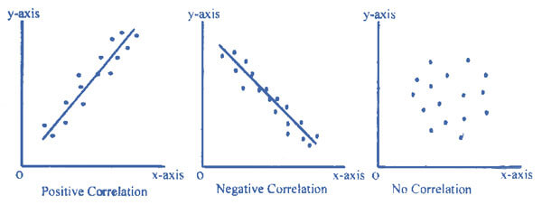

#### Summer NDVI v. surface temperatures

So in our exploration, one of the plots we made was mean August surface temperature against NDVI. We notice that this trend looks somewhat promising, and decide to plot a trend line. Do this by running the chunk below.

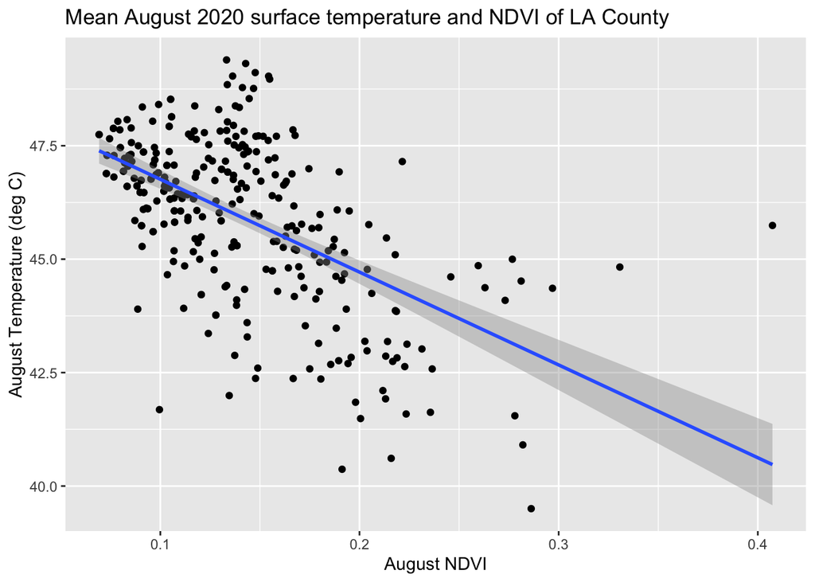

```r
LA_nbhds %>%
  dplyr::filter(NDVI_SUMMER > 0 & NDVI_SUMMER < 1) %>%
  ggplot() + geom_jitter(aes(x=NDVI_SUMMER, y=TEMP_SUMMER)) +
  geom_smooth(aes(x=NDVI_SUMMER, y=TEMP_SUMMER), method=lm) +
  labs(x = "August NDVI", y="August Temperature (deg C)") +
  ggtitle("Mean August 2020 surface temperature and NDVI of LA County")
```

##### Answer these questions:

1. Describe the relationship between August 2020 Mean Temperature and NDVI

### Part II: Understanding the surface energy balance model

We’re going be using equations throughout this class, so lets learn how to become more literate in equations. To do this we’re going to explain the components and then draw a conceptual model. This may take some time, but its an extremely important skill. So take a deep breath, be patient with yourself, and dive in.

Here is the somewhat simplified equation we will be using, based off of the equation on page 211 of Chapter 7 in Ecological Climatology by Bonan.

$$(1 - \alpha)S_{\downarrow} + L_{\downarrow} = L_{\uparrow} + H + \lambda E + G$$

##### Answer these questions:

Define each of the terms of the equation and include one sentence of what the flux is in plain language. If you need a hint, check out the chapter on [Surface Energy Fluxes](https://gauchospace.ucsb.edu/courses/pluginfile.php/10694510/mod_resource/content/2/Reading%20for%20Surface%20Energy%20Balance.pdf).

4. $(1 - \alpha)S_{\downarrow}$

To insert your conceptual model into this document: create a conceptual model by hand or on the computer and then turn it into a .jpg, or any photo file type. Include that photo in the assignment folder, and then use this code as a template to add it to this document: `![Caption](filename_conceptual_model.jpg)`

### Part III: Solving for surface temperature

The chunk below consists of functions needed to do the assignment. No need to change or do anything here, just run this chunk so the equations can be used later.

```r
# the following functions are needed to solve the surface energy balance and calculate latent heat

# Tetens eq. to solve for saturated vapor pressure (used in LE eq.)
sat_vp <- function(T){
  e <- 0.61078*exp(17.27*T/(T+237.3))
  return(e)
}

# surface energy balance returns surface temperature
# input is surface temperature, represented as x (in celsius)
# veg represents % veg cover, alpha is albedo, and eps is emissivity
seb <- function(x, veg=0, alpha=0.15, eps=0.95){
  r_w = 1/(veg*50) # scaler for veg
  L_inc = 0.9*sigma * (T_a+273.15)^4  # incoming longwave radiation [W/m^2]
  R_av = (K_inc*(1-alpha) + L_inc) # net available energy at surface [W/m^2]
  L_out = eps*sigma*(x+273.15)^4 # outgoing longwave radiation [W/m^2]
  H = 1.15*1005*(x-T_a)/r_H # sensible heat flux [W/m^2]
  E = 1.15*1005/66.5*(sat_vp(x) - sat_vp(T_a))/r_w # latent heat flux [W/m^2]
  val = - R_av + L_out + H + E
  return(val)
}

## returns bar plot of the different fluxes
plot_fluxes <- function(veg_cov){
  alpha=0.2
  range=c(1,100)
  x <- uniroot.all(seb, range, veg=veg_cov, alpha=0.2)
  r_w = 1/(veg_cov*50) # scaler for veg
  L_inc = 0.9*sigma * (T_a+273.15)^4  # incoming longwave radiation [W/m^2]
  R_av = (K_inc*(1-alpha) + L_inc) # net available energy at surface [W/m^2]
  L_out = eps*sigma*(x+273.15)^4 # outgoing longwave radiation [W/m^2]
  H = 1.15*1005*(x-T_a)/r_H # sensible heat flux [W/m^2]
  E = 1.15*1005/66.5*(sat_vp(x) - sat_vp(T_a))/r_w # latent heat flux [W/m^2]
  fluxes <- data.frame(flux=c("R_av","L_out","H","E"), value=c(R_av,L_out,H,E))
  fluxes$flux <- factor(fluxes$flux, levels=c("R_av", "L_out", "H","E"))
  plot <- ggplot(fluxes) + geom_col(aes(x=flux, y=value, fill=flux)) +
    ylab("energy [W/m^2]")
  return(plot)
}
```

In order to use this equation to test our hypothesis we are going to do a sensitivity analysis. To perform this, we vary one parameter at a time and observe how the output changes, which in this case is temperature. We’re first going to do an example together, and then you’ll do one on your own.

#### Albedo

We learned in class that albedo affects the amount of shortwave radiation entering the surface by reflecting some back. Albedo affects the available energy at the surface, which we will call $R_{av}$, through the equations:

$$S_{net} = S_{\downarrow}*(1-\alpha)$$

$$R_{av} = S_{net} + L_{\downarrow}$$

Where $\alpha$ represents albedo. Use the code below to explore the model outcomes, and to answer the questions below.

The following are other variables needed to use the model. No need to change these.

```r
eps = 0.95 # surface emissivity
T_a = 28 # ambient atm temp in Celsius
sigma = 5.6704*10^-8 #W/m^2/K^4 stefan-boltzmann constant
r_H = 20 # Sensible heat resistivity
K_inc = 800 # W/m^2, incoming shortwave radiation
```

This chunk runs the model, outputs the steady state temperature, and displays the graph of the sensitivity analysis.

```r
## Run the below code to solve for surface temperature
# temp_s is surface temperature
range = c(0,100)
test_albedo <- function(x){
  temp_s = uniroot.all(seb, range, alpha=x)
  return(temp_s)
}

# You can solve for surface temp by inputting specific values of albedo, where x is albedo - replace x with any value between 0 and 1.
test_albedo(x=0.9)
```

```
## [1] 28.88978
```

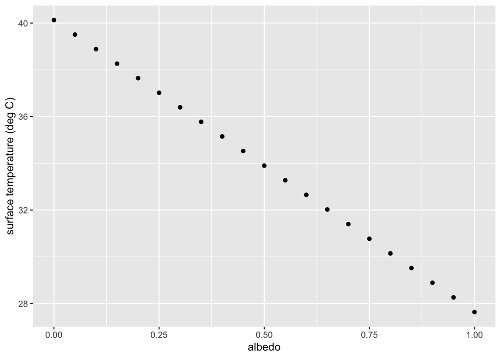

```r
# The code below runs the above function for every value of albedo in the 'alpha' vector below
# quick SA for veg parameter
alpha <- seq(0,1, by=0.05)
test <- sapply(X=alpha, FUN=test_albedo)
# combine input and output
albedo_df <- data.frame(alpha, test)
# plot data frame (do this together in discussion)
ggplot(albedo_df) + geom_point(aes(x=alpha, y=test)) +
  labs(x="albedo", y="surface temperature (deg C)")
```

##### Answer these questions:

12. What happens to the surface temperature when albedo increases?

#### Vegetation

Now its your turn do a sensitivity analysis based upon the amount of vegetation, but first we dive a little deeper into the latent energy equation.

Latent energy is a convective flux, which - from lecture - means that its magnitude is proportional to a gradient and inversely proportional to a resistence:

$$\lambda E \propto \frac{\Delta e}{r_W}$$

In reality, as we’ve seen in the reading, this equation is a bit more complicated. For now, dont get too stuck on this; all of the additional terms are related to converting the mass flux of water implied by a vapor gradient into an energy flux. This energy flux is a bit obscure (it’s not called “latent” for nothing), but it is the transport of energy away from the surface when there is net evaporation of water at the surface and then subsequent transport of water vapor from the surface to the atmosphere. We only include it to elaborate on the actual equations you are using and to ensure that the equation is dimensionally correct.

$$\lambda E = -\frac{\rho*C_p}{\gamma}*\frac{e_a - e_{*}[T_s]}{r_W}$$

Where $-\frac{\rho*C_p}{\gamma}$ represents the density of air, $\rho$ (kg/m$^3$), specific heat capacity, $C_p$ (J kg$^{-1}$ $^{\circ}$C$^{-1}$), and the psychrometric constant, $\gamma$ (Pa/$^{\circ}$C). All of these terms are fairly constant, so let’s move on to the second group of terms, which vary much more in time and space.

The numerator of the second part, $(e_a - e_{*}[T_s])$ corresponds to the $\Delta e$ term in the simplified equation above. It represents the gradient between the atmospheric vapor pressure, $e_a$ (Pa), and the surface vapor pressure, $e_{*}[T_s]$ (Pa). This gradient is almost always negative, because moisture in plants and the soil usually keeps the surface vapor pressure higher than the atmosphere. The resistance to vapor transfer between the surface and the atmosphere is $r_W$ (s/m). All things being equal, the resistance to vapor transport, $r_W$, is determined by amount of **vegetation** at the surface. Check out [section 7.2](https://gauchospace.ucsb.edu/courses/pluginfile.php/10694510/mod_resource/content/2/Reading%20for%20Surface%20Energy%20Balance.pdf) to learn more.